# What influences home value more weather or location?

## Data Collection Plan - Census Data

```python
# refine housing and income data by selecting relevant columns and renaming columns

median_income = median_income[["Geography","County","state","Mean income (dollars); Estimate; All households"]]
median_income = median_income.rename(columns={"state":"State","Mean income (dollars); Estimate; All households":"Median Income"})

median_home_value_acs = median_home_value_acs[["Geography","Estimate; Median value (dollars)"]]
median_home_value_acs = median_home_value_acs.rename(columns={"Estimate; Median value (dollars)":"ACS Home Value"})

zillow_home_value = zillow_home_value[["geography","Zhvi"]]
zillow_home_value = zillow_home_value.rename(columns={"geography":"Geography","Zhvi":"Zillow Home Value"})

zillow_bottom_tier = zillow_bottom_tier[["Geography","2018-12"]]
zillow_bottom_tier = zillow_bottom_tier.rename(columns={"2018-12":"Zillow Bottom Tier Home Value"})

zillow_top_tier = zillow_top_tier[["Geography","2018-12"]]
zillow_top_tier = zillow_top_tier.rename(columns={"2018-12":"Zillow Top Tier Home Value"})

# create a csv for the county and state data

output_data = median_income[["Geography","County","State"]]

output_data.to_csv("./Interim Data Files/State and County Info.csv", index=False, header=True)
```

## Data Collection Plan - Google API for Lat and Long

- I then imported the state and county data into the Get Lat and Lng for Counties jupyter notebook and made calls to the Google geocode API to collect latitude and longitude data. I exported a CSV to Interim Data Files to use with the weather data API.

```python
from config import gkey

locations = pd.read_csv("Interim Data Files/State and County Info.csv")

locations['Latitude'] = ""
locations['Longitude'] = ""

# Build URL using the Google MAps API

base_url = "https://maps.googleapis.com/maps/api/geocode/json?"

location=""

params={
    "key": gkey
}

# iterate through datafram and retrieve lat and lng info

for index, row in locations.iterrows():

    location = row['Geography']
    params["address"] = location

    response = requests.get(base_url,params=params).json()

    # extract results

    results = response['results']

    try:
        print(f"Retrieving Results for Index {index}: {location}.")

        locations.loc[index, 'Latitude'] = results[0]['geometry']['location']['lat']
        locations.loc[index, 'Longitude'] = results[0]['geometry']['location']['lng']

    except (KeyError, IndexError):
        print("Missing field/result... skipping.")

    print("------------")
```

## Data Collection Plan - aWhere API

- I then used the state and county daya with latitude and longitude to make API calls to aWhere's Historical Norms API to collect weather data for each county. I exported a CSV to Input Data to use in my final analysis.

```python
locations = pd.read_csv("Interim Data Files/State and County Info with Lat and Lng.csv")

locations['Avg Temperature'] = ""
locations['Max Temperature'] = ""
locations['Min Temperature'] =  ""
locations['Avg Percipitation'] = ""
locations['Min Humidity'] = ""
locations['Max Humidity'] = ""
locations['Avg Wind'] = ""

url = "https://api.awhere.com/v2/weather/locations"

lat = ""
lng = ""

headers = {"Authorization": "Bearer " + access_token}

#loop through rows, make API calls and store data

for index, row in locations.iterrows():
    lat = row['Latitude']
    lng = row['Longitude']

    query_url = f"{url}/{lat},{lng}/norms/01-01/years/2015,2018/?&units=usa"

    response = requests.get(query_url, headers=headers)
    response_json = response.json()

    try:
        print(f"Retrieving Results for Index {index}")

        locations.loc[index, 'Avg Temperature'] = response_json['meanTemp']['average']
        locations.loc[index, 'Max Temperature'] = response_json['maxTemp']['average']
        locations.loc[index, 'Min Temperature'] = response_json['minTemp']['average']
        locations.loc[index, 'Avg Percipitation'] = response_json['precipitation']['average']
        locations.loc[index, 'Min Humidity'] = response_json['minHumidity']['average']
        locations.loc[index, 'Max Humidity'] = response_json['maxHumidity']['average']
        locations.loc[index, 'Avg Wind'] = response_json['averageWind']['average']

    except (KeyError, IndexError):
        print("Missing field/result... skipping.")

    print("------------")
```

## Data Analysis

- I then imported the Income and Housing Data CSV and the Weather Data CSV to the Final Data Cleanup and Plot Generation jupyter notebook. I then merged the data into one data set and generated various graphs to communicate the trends observed in the data. I also exported a CSV and all of my plots to the Output Files Folder.

# What influences home value?

## Question 1 - Is there a correlation between weather and housing prices?

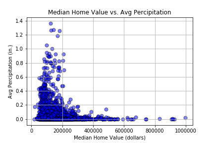

```python
from IPython.display import Image
Image("Figures/Med Home Value vs Avg Percip.png")
```

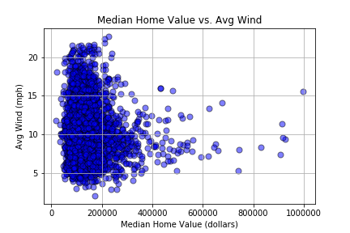

```python
Image("Figures/Med Home Value vs Avg Wind.png")
```

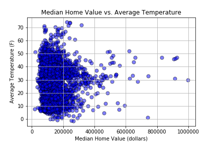

```python
Image("Figures/Med Home Value vs Avg Temp.png")
```

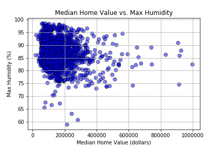

```python
Image("Figures/Med Home Value vs Max Humidity.png")
```

## Question 1

- There seems to be a correlation between rain fall and housing prices, there are hardly counties that have an average home price above 200,000 that have over an average daily rain fall of over .2".
- There also seems to be the same kind of relationship between average wind speed and home value. Very few counties with and median home price over 200,000 had an average wind speed over 15 mph.
- There is much less of a correlation between temperature and house value, there does seem to be a slight upper limit of around 50 degrees for the average temperature.
- There was no observable correlation between humidity and house value.

## Question 2 - Is there a correlation between location and housing prices?

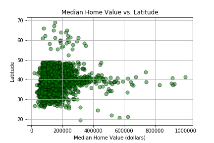

```python
Image("Figures/Best Weather - Med Home Value vs Latitude.png")
```

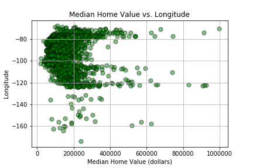

```python
Image("Figures/Best Weather - Med Home Value vs Longitude.png")
```

## Question 3 - What are the least expensive places to live with the nicest weather?

[figure not shown]

```python
Image("Figures/Heat Map of Cheapest Counties with the Best Weather and Location.png")
```

## Question 3

- When the data is filtered according to the criteria determined from the previous two questions and then refined by filtering out the highest median home value counties it it apparent that he some of the most afforadable nice places to live are in Virginia and North Carolina